# R per proletari - Episodio 2

Bollettino della qualità dell’aria per il glorioso popolo lavoratore

Proletari della tastiera, liberatevi dal giogo del copia-incolla  
Respingete i fogli di calcolo borghesi!

Autore/Autrice

Andrea Bazzano

## Introduzione

Compagno, con questo report scritto con `R` e `Quarto`, scaricheremo ed elaboreremo i dati di qualità dell’aria forniti dai fratelli socialisti dell’Emilia-Romagna.

Nel documento `report.qmd` troverai sia passaggi di testo, sia blocchi di codice R racchiusi tra tripli backtick `` ``` ``` ``, sia frammenti di codice in linea delimitati da singoli backtick `` ` ` ``.  
Al termine della compilazione, otterrai report HTML e PDF completi, in cui testo e risultati di calcolo marceranno insieme: il giogo borghese di Excel è stato spezzato e la rivoluzione dei dati è iniziata!

## Materiali

I dati necessari vengono scaricati dall’*application programming interface* (API) del robusto database di [ARPA Emilia-Romagna](https://dati.arpae.it/api/3/action/datastore_search?resource_id=4dc855a1-6298-4b71-a1ae-d80693d43dcb&limit=5), grazie a funzioni appositamente forgiate e custodite nel file `R/data_download.R`.

In alternativa, è possibile caricare i dati anche da file `.csv` o `xlsx`: compagno, anche dai formati più borghesi può nascere un report degno della pianificazione quinquennale.

Dopo il download, i dati vengono ripuliti e integrati con le informazioni delle anagrafiche delle stazioni e dei parametri, ottenute direttamente dal Centro Dati del Popolo di [ARPA Emilia-Romagna](https://dati.arpae.it/dataset/qualita-dell-aria-rete-di-monitoraggio).

Con le funzioni in `R/analisi_numerica.R` vengono svolte le analisi previste dal Decreto Legislativo 152/2010 prodotto dall’assemblea del popolo, sorvolando su qualche controllo borghese riguardante la numerosità dei valori: la rivoluzione non può aspettare!

In `R/analisi_grafica.R` i grafici si ergono come bandiere rosse al vento: approvati dal Komintern e benedetti dal compagno Lenin, pronti a diffondere tra le masse il glorioso progetto internazionale socialista.

Infine, in `R/report_helper.R` orchestra tabelle, grafici e commenti militanti con funzioni automatiche come `crea_sezione_parametro()`. Le frasi? Direttamente dal libretto rosso del compagno Mao, per un report che marcia compatto verso l’illuminazione proletaria.

## Risultati del 06/09/2025 per la provincia di Reggio Emilia

### Polveri sottili PM10

Tabella dei risultati per Polveri sottili PM10 misurati il 2025-09-06

| Stazione | Comune | Concentrazione (µg/m³) |
| --- | --- | --- |
| CASTELLARANO | CASTELLARANO | 14 |
| S. LAZZARO | REGGIO NELL’EMILIA | 13 |
| FEBBIO | VILLA MINOZZO | 8.0 |
| S. ROCCO | GUASTALLA | 17 |
| TIMAVO | REGGIO NELL’EMILIA | 19 |

- Non si registrano superamenti limite giornaliero di 50 µg/m³ presso le stazioni di misura considerate.

### Polveri sottili PM2.5

Tabella dei risultati per Polveri sottili PM2.5 misurati il 2025-09-06

| Stazione | Comune | Concentrazione (µg/m³) | PM2.5/PM10 |
| --- | --- | --- | --- |
| CASTELLARANO | CASTELLARANO | 7.0 | 0.50 |
| S. LAZZARO | REGGIO NELL’EMILIA | 7.0 | 0.54 |
| S. ROCCO | GUASTALLA | 9.0 | 0.53 |

Il PM2.5 non prevede limiti orari giornalieri secondo normativa: si riporta quindi il valore medio per le stazioni considerate.

### Diossido di azoto

Tabella dei risultati per Diossido di azoto misurati il 2025-09-06

| Stazione | Comune | Min (µg/m³) | Max (µg/m³) | ≥ 200 µg/m³ | ≥ 400 µg/m³ per 3h |
| --- | --- | --- | --- | --- | --- |
| CASTELLARANO | CASTELLARANO | 2.0 | 14 | 0 | 0 |
| S. LAZZARO | REGGIO NELL’EMILIA | 4.0 | 44 | 0 | 0 |
| FEBBIO | VILLA MINOZZO | 1.6 | 4.4 | 0 | 0 |
| S. ROCCO | GUASTALLA | 6.0 | 29 | 0 | 0 |
| TIMAVO | REGGIO NELL’EMILIA | 7.0 | 80 | 0 | 0 |

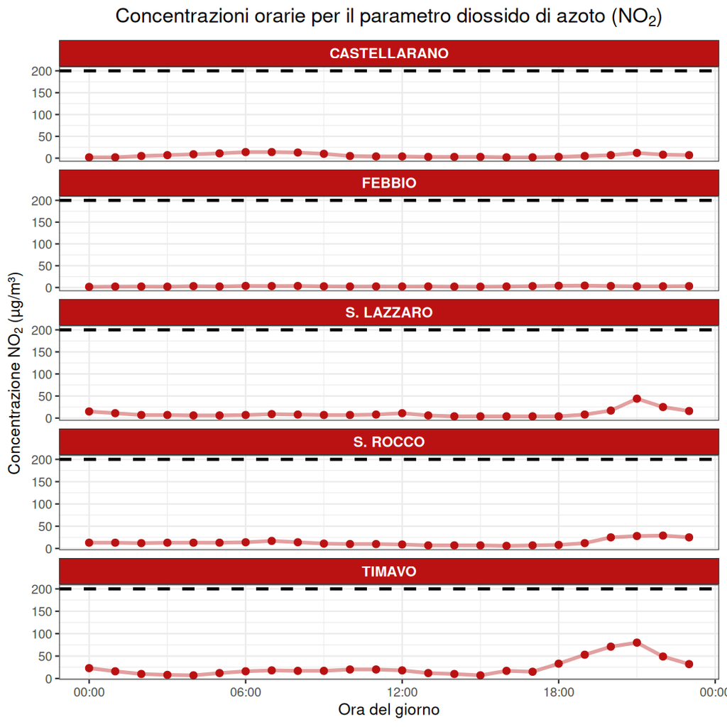

- Non si registrano superamenti del limite orario di 200 µg/m³ presso le stazioni di misura considerate.
- Non si registrano superamenti del limite di 400 µg/m³ per tre ore consecutive presso le stazioni di misura considerate.

### Diossido di zolfo

Non ci sono dati disponibili per il parametro diossido di zolfo ( SO₂ ) forse le stazioni di misura sono state sabotate da elementi borghesi.

### Monossido di carbonio

Tabella dei risultati per Monossido di carbonio misurati il 2025-09-06

| Stazione | Comune | Min 8h MA (mg/m³) | Max 8h MA (mg/m³) | ≥ 10 mg/m³ |
| --- | --- | --- | --- | --- |
| TIMAVO | REGGIO NELL’EMILIA | 0.21 | 0.40 | 0 |

- Non si registrano superamenti del valore limite di 10 mg/m³ sulla media mobile (MA) di 8 ore presso le stazioni di misura considerate.

### Ozono

Tabella dei risultati per Ozono misurati il 2025-09-06

| Stazione | Comune | Min (µg/m³) | Max (µg/m³) | Min 8h MA (µg/m³) | Max 8h MA (µg/m³) | ≥ 120 µg/m³ | ≥ 180 µg/m³ | ≥ 240 µg/m³ per 3h |
| --- | --- | --- | --- | --- | --- | --- | --- | --- |
| CASTELLARANO | CASTELLARANO | 32 | 110 | 44 | 98 | 0 | 0 | 0 |
| S. ROCCO | GUASTALLA | 15 | 110 | 24 | 100 | 0 | 0 | 0 |

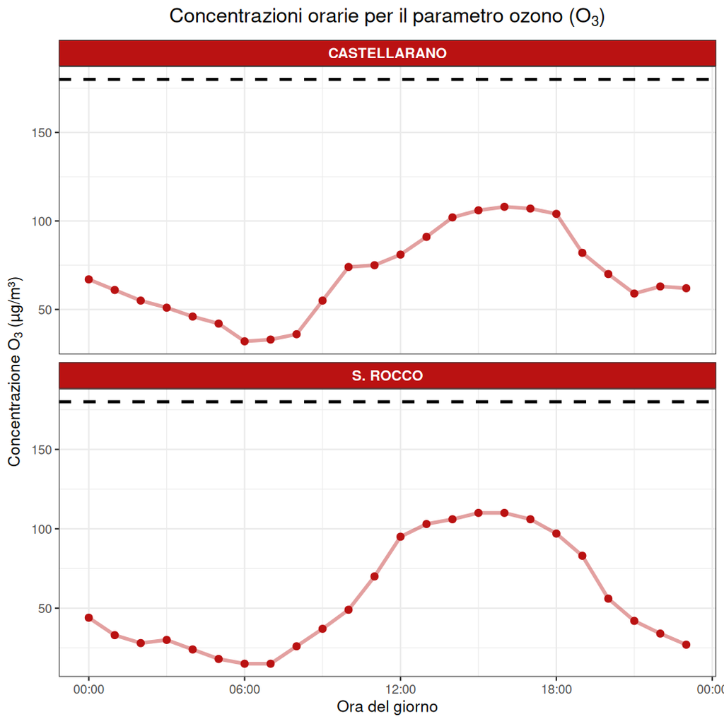

- Non si registrano superamenti del valore obiettivo di 120 µg/m³ (massima media mobile - MA - sulle 8 ore) presso le stazioni di misura considerate.
- Non si registrano superamenti della soglia di informazione di 180 µg/m³ oraria presso le stazioni di misura considerate.
- Non si registrano superamenti della soglia di allarme di 240 µg/m³ per tre ore consecutive presso le stazioni di misura considerate.